# Seaborn - categorical plotting

```python
import seaborn as sns
%matplotlib inline
tips = sns.load_dataset('tips')
tips.head()
```

|  | total_bill | tip | sex | smoker | day | time | size |
| --- | --- | --- | --- | --- | --- | --- | --- |
| 0 | 16.99 | 1.01 | Female | No | Sun | Dinner | 2 |
| 1 | 10.34 | 1.66 | Male | No | Sun | Dinner | 3 |
| 2 | 21.01 | 3.50 | Male | No | Sun | Dinner | 3 |
| 3 | 23.68 | 3.31 | Male | No | Sun | Dinner | 2 |
| 4 | 24.59 | 3.61 | Female | No | Sun | Dinner | 4 |

**ToC**

- Barplot
- Countplot
- Boxplot
- Violin plot
- Strip plot
- Swarm plot

# Barplot

Barplot is used to indicate some measure of central tendancy. Seaborn adds some descriptors to indicate the variance in the data. Call this with a categorical column in X and numerical column for Y

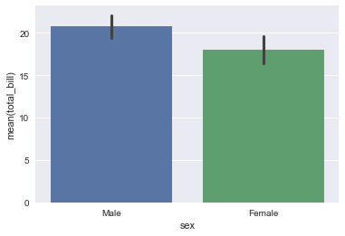

```python
sns.barplot(x='sex', y='total_bill', data=tips)
```

Thus the average bill for men was higher than women.

## Countplot

If you want a regular bar chart that shows the count of data, then do a `countplot`

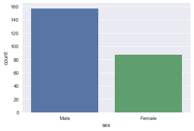

```python
sns.countplot(x='sex', data=tips)
```

## Boxplot

Boxplots are very common. It is used to display distribution of data as well as outliers. A boxplot splits the data into 4 `quantiles` or `quartiles`. The `median` is represented as a horizontal line with the quartile +- medain in solid shade. The end of the whiskers may represent the ends of the remaining quartiles

[figure not shown]

If outliers are calculated, then whiskers are shorter and values greater than `1.5` times the `IQR` - Inter Quartile Range are considered outliers.

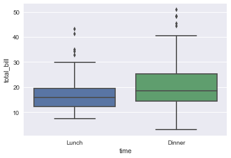

```python
sns.boxplot(x='time', y='total_bill', data=tips)
```

We can interpret this as people spend more on dinner on average than lunch. The median is higher. Yet there is higher variability as well with the amount spent on dinner. The lowest being lower than lunch.

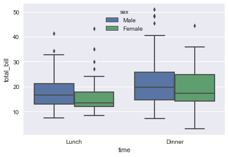

```python
sns.boxplot(x='time',y='total_bill', data=tips, hue='sex')
```

## Violin plot

A violin plot builds on a boxplot by showing KDE of the data distribution.

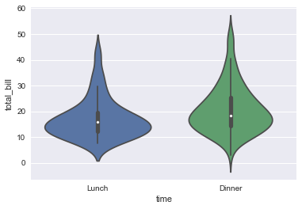

```python
sns.violinplot(x='time',y='total_bill', data=tips)
```

You can see, lunch bills are tighter around the median compared to dinner. The `Q3` of dinner is long, which can be noticed in the spread of the green violin plot.

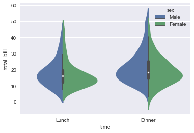

```python
sns.violinplot(x='time', y='total_bill', data=tips, hue='sex', split=True)
```

From this plot, we assert our experience so far that women's bills are lesser than men - the width of the violin is higher on the lower end.

## Stirp plot

Strip plot is like a scatter plot for a categorial data. You specify a categorial column for X and numeric for Y.

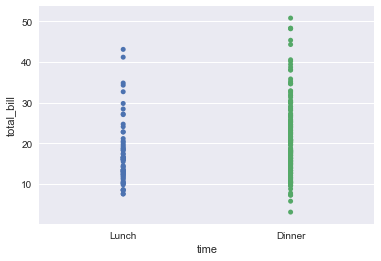

```python
sns.stripplot(x='time', y='total_bill', data=tips)
```

To make out the data distribution, you can add some jitter to the plot. Jitter will shift the points laterally in a random manner.

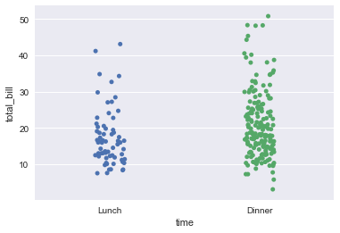

```python
sns.stripplot(x='time', y='total_bill', data=tips, jitter=True)
```

## Swarm plot

Swram plots are a combination of violin and strip plots. It shows the real data distribution using actual point values.

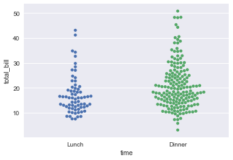

```python
sns.swarmplot(x='time', y='total_bill', data=tips)
```

You can combine a violin and swarm plot to see how the KDE is calculated and smooths

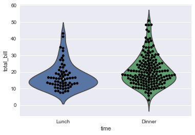

```python
sns.violinplot(x='time', y='total_bill', data=tips)
sns.swarmplot(x='time', y='total_bill', data=tips, color='black')
```